# Red Wine Quality Exploratory Data Analysis by Saul Geller

Looking at fixed acidity vs density, with a color gradient representing alcohol content, as well as looking at it over different qualities of wine, there looks to be a very strong relationship between high percent alcohol wines and fixed acidity, though they have no correlation when I looked at just fixed acidity vs alcohol in the bivariate section.

Though the most obvious relationship is between alcohol and density, most of the ligher color points are on the left side of the first graph. Looking at this split into different graphs for every quality, this effect holds true mainly only for wines with scores of 4, 5, and 6. While wines with scores of 3 and 8 had too few points to establish a pattern, wines with a quality of 7 seemed to have less of a relationship between alcohol and fixed acidity.

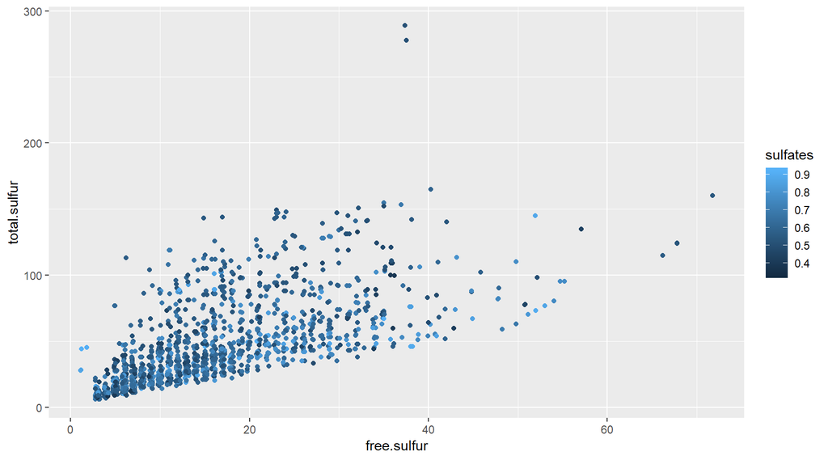

I also looked at sulfates vs free sulfur dioxide in the bivariate section but I wanted to try seeing if there was a pattern when I included total sulfur dioxide as well, as perhaps the sulfur additives were getting bound and would thus not be free.

Because the sulfates distribution had some far right outliers, I only used data up to the 95th percentile of the sulfates distribution so the color differences would be more even.

However, there didn’t seem to be any apparent pattern to sulfate level versus either of these variables. There is a clear positive association between free sulfur and total sulfur, which is to be expected.

```
##
## Call:
## lm(formula = quality ~ alcohol, data = rw_df)
##
## Residuals:
##     Min      1Q  Median      3Q     Max
## -2.8442 -0.4112 -0.1690  0.5166  2.5888
##
## Coefficients:
##             Estimate Std. Error t value Pr(>|t|)
## (Intercept)  1.87497    0.17471   10.73   <2e-16 ***
## alcohol      0.36084    0.01668   21.64   <2e-16 ***
## ---
## Signif. codes:  0 '***' 0.001 '**' 0.01 '*' 0.05 '.' 0.1 ' ' 1
##
## Residual standard error: 0.7104 on 1597 degrees of freedom
## Multiple R-squared:  0.2267, Adjusted R-squared:  0.2263
## F-statistic: 468.3 on 1 and 1597 DF,  p-value: < 2.2e-16
```

```
## [1] 5.212582e-17
```

```
##
## Call:
## lm(formula = quality ~ alcohol + vol.acid + citric.acid + sulfates,
##     data = rw_df)
##
## Residuals:
##      Min       1Q   Median       3Q      Max
## -2.71408 -0.38590 -0.06402  0.46657  2.20393
##
## Coefficients:
##             Estimate Std. Error t value Pr(>|t|)
## (Intercept)  2.64592    0.20106  13.160  < 2e-16 ***
## alcohol      0.30908    0.01581  19.553  < 2e-16 ***
## vol.acid    -1.26506    0.11266 -11.229  < 2e-16 ***
## citric.acid -0.07913    0.10381  -0.762    0.446
## sulfates     0.69552    0.10311   6.746 2.12e-11 ***
## ---
## Signif. codes:  0 '***' 0.001 '**' 0.01 '*' 0.05 '.' 0.1 ' ' 1
##
## Residual standard error: 0.6588 on 1594 degrees of freedom
## Multiple R-squared:  0.3361, Adjusted R-squared:  0.3345
## F-statistic: 201.8 on 4 and 1594 DF,  p-value: < 2.2e-16
```

```
## [1] 3.85297e-17
```

I used linear regression to try and find a model to best explain the quality score output based on certain chemical properties of the wine. Looking at just alcohol as the explanatory variable there was a clear statistically significant effect on quality. With an R-squared value of 0.226, alcohol level only explains about 23% of the quality scores variance.

Adding in other variables that shared a correlation with quality, and none that were associated with each other, the R-squared value improved to about 0.334. One of the variables, citric acid level, did not have a statistically significant relationship however.

```
##
## Call:
## lm(formula = density ~ fixed.acid, data = rw_df)
##
## Residuals:
##        Min         1Q     Median         3Q        Max
## -0.0064452 -0.0007700  0.0000738  0.0009434  0.0055816
##
## Coefficients:
##              Estimate Std. Error t value Pr(>|t|)
## (Intercept) 9.907e-01  1.716e-04 5774.70   <2e-16 ***
## fixed.acid  7.242e-04  2.018e-05   35.88   <2e-16 ***
## ---
## Signif. codes:  0 '***' 0.001 '**' 0.01 '*' 0.05 '.' 0.1 ' ' 1
##
## Residual standard error: 0.001405 on 1597 degrees of freedom
## Multiple R-squared:  0.4463, Adjusted R-squared:  0.4459
## F-statistic:  1287 on 1 and 1597 DF,  p-value: < 2.2e-16
```

```
## [1] 9.383608e-20
```

```
##
## Call:
## lm(formula = density ~ fixed.acid + alcohol, data = rw_df)
##
## Residuals:
##        Min         1Q     Median         3Q        Max
## -0.0046132 -0.0006805 -0.0001247  0.0006388  0.0045998
##
## Coefficients:
##               Estimate Std. Error t value Pr(>|t|)
## (Intercept)  9.994e-01  3.116e-04 3207.75   <2e-16 ***
## fixed.acid   6.936e-04  1.599e-05   43.38   <2e-16 ***
## alcohol     -8.089e-04  2.612e-05  -30.96   <2e-16 ***
## ---
## Signif. codes:  0 '***' 0.001 '**' 0.01 '*' 0.05 '.' 0.1 ' ' 1
##
## Residual standard error: 0.001111 on 1596 degrees of freedom
## Multiple R-squared:  0.6541, Adjusted R-squared:  0.6537
## F-statistic:  1509 on 2 and 1596 DF,  p-value: < 2.2e-16
```

```
## [1] 6.306714e-20
```

Even though density is not my main output of this dataset, I was still interested in how and why fixed acidity had a positive correlation with it. So using linear regression, fixed acidity does have a statistically significant relationship with density and by itself has an R-squared of 0.45. Combined with alcohol, which had no correlation with fixed acidity, the R-squared jumps to 0.65.

# Multivariate Analysis

### Talk about some of the relationships you observed in this part of the investigation. Were there features that strengthened each other in terms of looking at your feature(s) of interest?

In my investigation, though I thought free sulfur levels might have an effect on pH, I did not find any evidence of that in the bivariate section. Looking at it across different qualities, I still did not find any pattern or associations. So as far as I can tell, free sulfur did not have an effect on pH, despite how free sulfur dioxide in the form of bisulfites in solution can dissassociate further and add more hydrogen cations to solution.

### Were there any interesting or surprising interactions between features?

Looking at fixed acidity versus density, a direct correlation became apparent in the bivariate section that I had no explanation for. Looking at it compared with percent alcohol levels, there did seem to be a hidden relationship between alcohol content and fixed acidity that only held true for certain quality scores. Higher alcohol content causes lower density which is why I thought alcohol content might also contribute to how fixed acidity relates to density.

Without further investigation I can’t say if this relationship between alcohol and fixed acidity that only occurred at certain qualities is causal or even real; it may just be statistical noise. But it may be something interesting to look into with further data.

### OPTIONAL: Did you create any models with your dataset? Discuss the strengths and limitations of your model.

I did create some standard linear regression models to try and fit a line that would explain how quality score varied with other chemical properties of the wine. The model did find clear statistical evidence that alcohol, volatile acidity, and sulfates had an effect on quality, but the linear model only explained about 33% of how quality varied.

I also looked at how density could be explained through fixed acidity and alcohol content.

# Final Plots and Summary

### Plot One

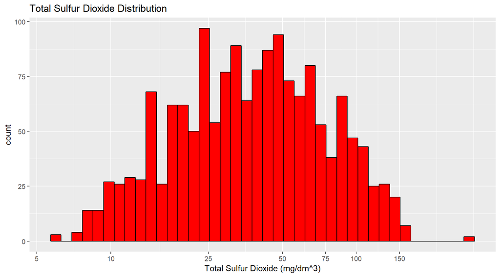

### Description One

Here is the total sulfur dioxide distribution with a logarithmic scale transformation. On a linear scale, the distribution was long-tailed, but with this logarithmic scale the distribution looks very normal, albeit with some significant variance. This tells me that most wines have a relatively low total sulfur dioxide level, yet there are then many outliers who have much higher sulfur dioxide levels compared to the bulk of the wines.

### Plot Two

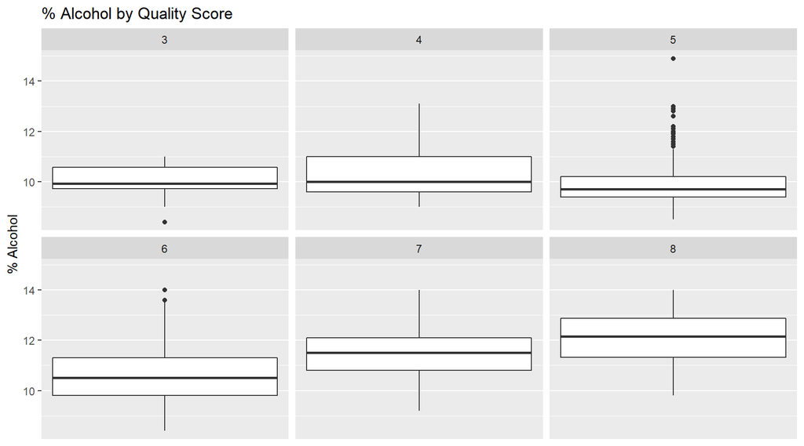

### Description Two

In the correlation matrix I saw that alcohol content had the strongest linear relationship to the main output of the dataset, quality score. Looking at the boxplots of % alcohol separated by quality, I can see that wines with a score of 8 had a higher alcohol content than wines with a score of 7, which were higher in alcohol than wines with a score of 6, which were higher than wines with lower scores. But, interestingly, wines with a score of 3, 4, and 5 did not have very different alcohol levels, though the wines with a score of 5’s distribution did have a lot of outliers.

### Plot Three

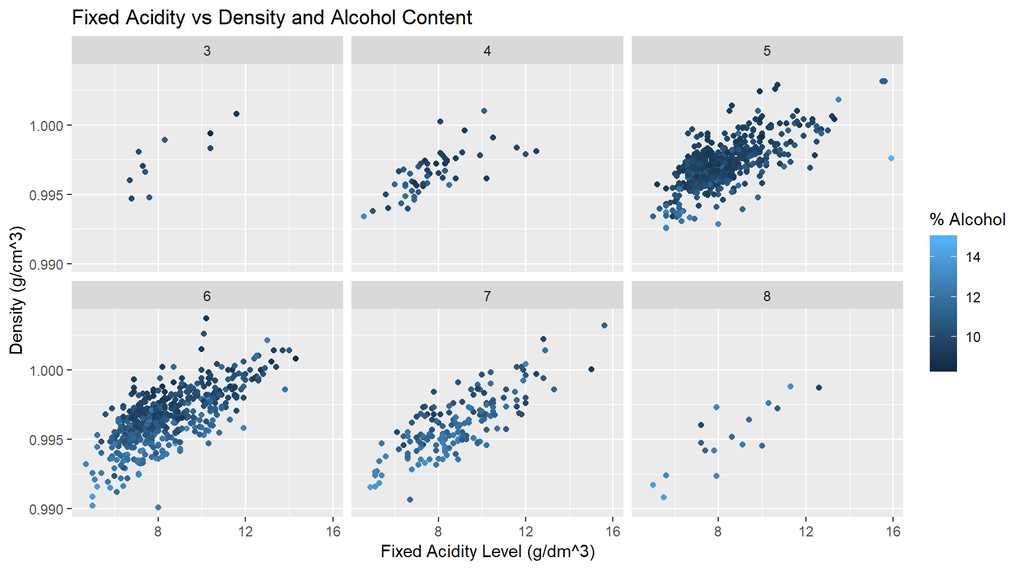

# Reflection

Looking through this dataset, I was able to determine that alcohol content, volatile acidity, and sulfate additive level were all statistically significant contributors to quality score. Sulfates are added to wine to act as antioxidants anti-microbial agents, and their level had a positive association with quality. Volatile acidity is basically the amount of acetic acid present in the wine, which at higher levels can give the wine a vinegar taste, and had a negative association with quality. Alcohol content had a positive relationship with quality, but only up to a point, as lower scoring wines had pretty similar alcohol content distributions.

There were many suprising things I found in the dataset, such as free sulfur dioxide’s lack of a relationship with pH, alcohol’s relatively strong relationship with quality, as well as fixed acidity’s relationship with density. I struggled to find an explanation for why fixed acidity had a somewhat strong (correlation of 0.67) relationship with density. Looking at how percent alcohol could maybe contribute to it didn’t help unfortunately.

For future work I would want to look into this relationship between density and fixed acidity, and into fixed acidity in general to establish how it can affect density. Now, density in the context of this dataset, isn’t a very important as it doesn’t have much of a relationship with the main output, quality score. But I am still curious as to how fixed acidity would affect density, and finding out why could reveal interesting findings, even if they wouldn’t be very crucial to the context of this particular dataset.

Also I would probably look for additional chemical properties to test against quality score to see if maybe a better model can be found to predict quality.